# Demonstration of Data Mining Techniques on Education Data

Alex Dragonetti

2024-08-04

# 1 Overview

The following is meant to be a demonstration of Data cleaning, preparation, Exploratory Data Analysis (EDA), and various statistical techniques, as well as their possible applications with School District data.

All data used for this project was collected from the School District of Philadelphia’s District Performance Office. The data used below, and their descriptions, were found on their website: https://www.philasd.org/performance/.

## 1.1 Introduction to the Data

We felt it was important, for demonstration purposes, to include data related to both school attributes and school performance. The datasets that we are beginning with are:

*College Matriculation - Students are considered to have matriculated if they enrolled at a postsecondary institution that reports information to the National Student Clearinghouse (NSC).

*Graduation - Contains data on the graduation rate of ninth grade cohorts (ie, the ninth grade cohort of SY 2019-2020 would generally be eligible for graduating at the end of SY 2022-2023).

*Average Daily Attendance - Contains daily attendance at 3 different reporting times throughout SY 22-23. It does not specify time of year in the dataset or description. Since this is only meant to be a demonstration of techniques, these values will be averaged, and each school’s average will be included in further analysis.

*90% Attendance - This dataset contains the number and percentage of enrolled students in each grade that attended at least 90% of instructional days. While the data contains breakdowns of different student groups, we will only use data for all students in our larger analysis.

*Food Insecurity - Contains school-level information about household food insecurity status. This information is based on responses to questions about food insecurity that appear on the parent/guardian Philly School Experience Survey (PSES). Only schools that met the minimum response rate threshold for the parent/guardian survey are included.

```r
setwd("C:\\Users\\Alex\\Documents\\R\\Grad\\536\\Datasets")

df.col<-read.csv("SDP_College_Matriculation_2022-2023.csv")
df.grad<-read.csv("SDP_Graduation_Rates_School_S_2024-04-01.csv")
df.ada<-read.csv("Student_ADA_Yearly_School_20240228.csv")
df.a90<-read.csv("Student_Attendance_90_School_20240313.csv")

#This is only sheet 3 of the "2022-2023 Household Food Insecurity" file
df.food<-read_excel("22-23 Food by School.xlsx")
```

# 2 Initial EDA and Preparing the Data

## 2.1 Original Data

### 2.1.1 Food Security Rate Data

First, we will look at the food security data. We expect this dataset to have the most missing values, as a school’s values are only included if it met a response criterion (while not stated on the District’s website, we believe the criterion is 10% or more eligible households respond). We will also format the `ULCS.Code` variable name to align with other datasets.

Notably, this dataset contains a different formatting for the `School.Name` variable: this dataset calls school number 1010 “Bartram, John High School”, compared to the other datasets’ “John Bartram High School”. While this is understandable, as many district schools named after a person are referred to by the last name only, It is our recommendation to adopt a more uniform formatting for school names. While removing school names from this dataset will lead to missing values in our full dataset, schools can be identified by `ULCS.Code` as well.

```r
colnames(df.food)[1]<-"ULCS.Code"
df.food<-df.food[,-2]

summary(df.food)
```

```
##    ULCS.Code       Sector          Learning Network
##  Min.   :1010   Length:323         Length:323
##  1st Qu.:3320   Class :character   Class :character
##  Median :4270   Mode  :character   Mode  :character
##  Mean   :4724
##  3rd Qu.:6425
##  Max.   :8890
##
##  Number of Responding Households Household Response Rate
##  Length:323                      Min.   :0.00000
##  Class :character                1st Qu.:0.06259
##  Mode  :character                Median :0.21231
##                                  Mean   :0.26334
##                                  3rd Qu.:0.37744
##                                  Max.   :1.08824
##
##  Met Reporting Threshold Number of Responses to Food Insecurity Questions
##  Length:323              Min.   :  6.0
##  Class :character        1st Qu.: 57.5
##  Mode  :character        Median :102.0
##                          Mean   :145.5
##                          3rd Qu.:182.5
##                          Max.   :807.0
##                          NA's   :100
##  High or marginal food security rate High or marginal food security count
##  Min.   :0.3636                      Min.   :  5.0
##  1st Qu.:0.6956                      1st Qu.: 42.5
##  Median :0.7469                      Median : 78.0
##  Mean   :0.7441                      Mean   :112.4
##  3rd Qu.:0.8106                      3rd Qu.:142.5
##  Max.   :0.9546                      Max.   :654.0
##  NA's   :100                         NA's   :100
##  Low food security rate Low food security count Very low food security rate
##  Min.   :0.0000         Min.   :  0.00          Min.   :0.00000
##  1st Qu.:0.1107         1st Qu.:  8.00          1st Qu.:0.05760
##  Median :0.1561         Median : 15.00          Median :0.08824
##  Mean   :0.1583         Mean   : 20.91          Mean   :0.09763
##  3rd Qu.:0.1920         3rd Qu.: 26.00          3rd Qu.:0.12216
##  Max.   :0.4298         Max.   :118.00          Max.   :0.36585
##  NA's   :100            NA's   :100             NA's   :100
##  Very low food security count
##  Min.   : 0.00
##  1st Qu.: 5.00
##  Median : 9.00
##  Mean   :12.22
##  3rd Qu.:16.50
##  Max.   :69.00
##  NA's   :100
```

Of note:

*Exactly 100 missing values related to food security count - we can assume that means 100 schools do not have their data represented here.* Very high variance in the number of responses - while we would expect a high range, given the district has schools of various sizes, the minimum of 6 is starkly different from the maximum of 807. *Household response rate would appear to be a percentage (0-1) of the number of households that responded. However, two schools - Abram Jenks and Fox Chase - have a value over 1. This would suggest an error in data collection, so we will change those to values to 1 if we use this variable for anything later on.

This dataset also has information regarding all schools’ status (Alternative, Charter, District) and Neighborhood Network (region of the city). We expect to have more District schools than Charter or Alternative, but we are interested that our dataset has a fairly even distribution across the neighborhood networks, which we can check for using the `table` function.

```r
table(df.food$Sector)
```

```
##
## Alternative     Charter    District
##          23          83         217
```

```r
table(df.food$`Learning Network`)
```

```
##
## Acceleration     Charters   Innovation    Network 1   Network 10   Network 11
##           14           83           18           19           14           16
##   Network 12   Network 13    Network 2    Network 3    Network 4    Network 5
##           10           12           14           16           13           17
##    Network 6    Network 7    Network 8    Network 9  Opportunity
##           16           14           16           14           17
```

### 2.1.2 College Matriculation Data

Similar to what we did for the Food Security data, we will check information on variables to look for outliers, patterns, etc.

```r
summary(df.col)
```

```
##  School.Year          ULCS.Code    School.Name        Number.of.Graduates
##  Length:53          Min.   :1010   Length:53          Min.   :  4.0
##  Class :character   1st Qu.:2620   Class :character   1st Qu.: 65.0
##  Mode  :character   Median :5090   Mode  :character   Median : 88.0
##                     Mean   :4707                      Mean   :120.2
##                     3rd Qu.:6060                      3rd Qu.:140.0
##                     Max.   :8780                      Max.   :562.0
##  First.Fall.Matriculation.Rate
##  Length:53
##  Class :character
##  Mode  :character
##
##
##
```

Our summary shows very little of interest, aside from the matriculation rate variable being considered a character variable by R. This is likely because of the % symbol. We will remove the %, allowing us to use the numeric value for further analysis, including a simple scatter plot. We will also remove redundant variables, like `School.Year` (since this is all data from SY 22-23).

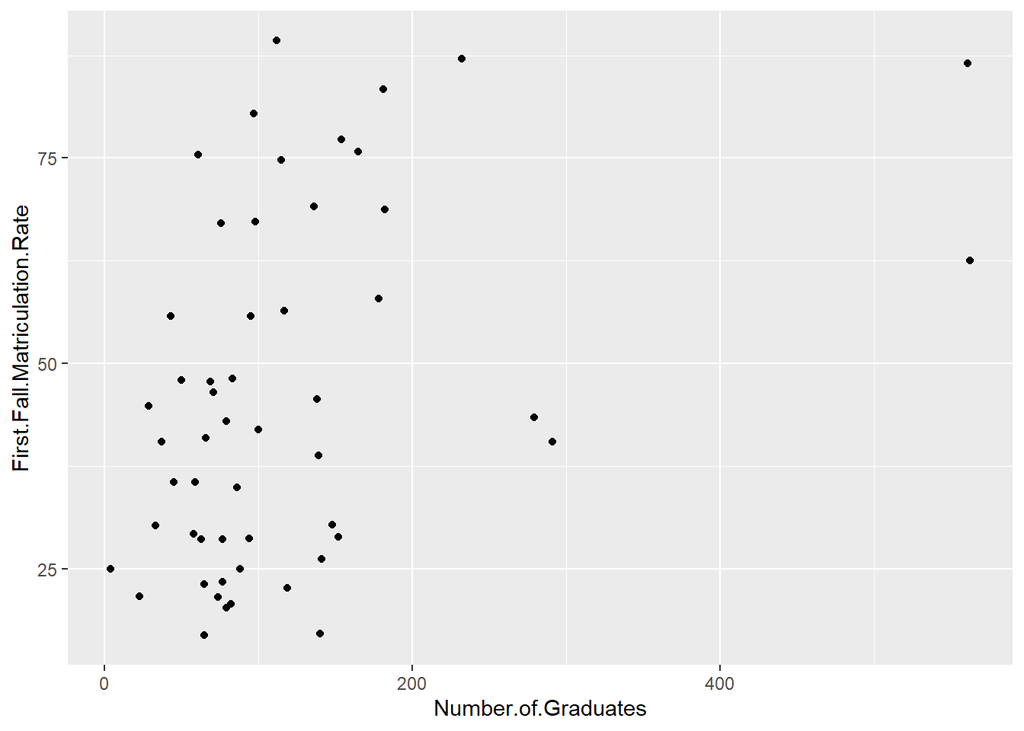

```r
df.col<-df.col[,-3]
df.col <- df.col %>%
  mutate(First.Fall.Matriculation.Rate = as.numeric(sub("%", "", First.Fall.Matriculation.Rate)))

ggplot(df.col, aes(x=Number.of.Graduates, y=First.Fall.Matriculation.Rate))+
  geom_point()
```

While we were not looking for a pattern, this gives us a good idea of the average size of each school’s graduating class, showing us that schools of varying sizes will be represented by our analyses.

### 2.1.3 Attendance Data

We have two datasets related to attendance: one with schools’ attendance rate, and one with the number and percent of students with 90% daily attendance or higher. As stated in the introduction, the daily attendance values will be averaged, and each school’s average will be included in further analysis.

We will also create a subset of the 90% dataset that only has total school data. In doing so, we will eliminate redundant variables (there is no need to specify school year, group, etc, since the output data is all one school year and one type of data).

Similar to our matriculation dataset, we will need to change character variables `Attendance.90.N` and `Attendance.90.Rate` to numeric for later analysis.

```r
df.ada2 <- df.ada %>%
  group_by(ULCS.Code) %>%
  summarize(Mean.Attendance = mean(Average.Daily.Attendance..YTD., na.rm = TRUE))

summary(df.ada2$Mean.Attendance)
```

```
##    Min. 1st Qu.  Median    Mean 3rd Qu.    Max.
##   74.12   84.54   88.94   88.22   92.10   97.76
```

```r
df.a<-subset(df.a90, Category=="All Students" & School.Year=="2022-2023")
df.a<-df.a[,-c(1,2,5,6)]

colnames(df.a)[3]<-"Total.Students"
colnames(df.a)[4]<-"Attendance.90.N"
colnames(df.a)[5]<-"Attendance.90.Rate"


df.a$Attendance.90.N <- suppressWarnings(as.numeric(df.a$Attendance.90.N))
df.a$Attendance.90.Rate <- suppressWarnings(as.numeric(df.a$Attendance.90.Rate))
```

### 2.1.4 Graduation

Finally, we will conduct EDA on our graduation dataset while preparing it for a larger merge. Please note: cohort is 9th grade cohort, meaning, we will use data from students who were 9th graders in the cohort year (most likely eligible to graduate at the end of SY 22-23).

```r
df.g<-subset(df.grad, group=="All Students" & cohort=="2019-2020")
df.g2<-df.g[,-c(1,5,6,7)]

colnames(df.g2)[1]<-"ULCS.Code"
colnames(df.g2)[3]<-"Sector"
colnames(df.g2)[2]<-"School.Name"
colnames(df.g2)[4]<-"Grad.Cohort.N"
colnames(df.g2)[5]<-"Grad.N"
colnames(df.g2)[6]<-"Grad.Rate"

summary(df.g2)
```

```
##    ULCS.Code    School.Name           Sector          Grad.Cohort.N
##  Min.   :1010   Length:81          Length:81          Min.   :  2
##  1st Qu.:3240   Class :character   Class :character   1st Qu.: 50
##  Median :5150   Mode  :character   Mode  :character   Median : 92
##  Mean   :5127                                         Mean   :119
##  3rd Qu.:7061                                         3rd Qu.:143
##  Max.   :8891                                         Max.   :773
##     Grad.N           Grad.Rate
##  Length:81          Length:81
##  Class :character   Class :character
##  Mode  :character   Mode  :character
##
##
##
```

Again, we see numeric variables treated as character, this time likely due to the letter s (lower and uppercase) being used. We will have R treat them as missing values to conduct our EDA and further analyses.

```r
df.g2$Grad.N[df.g2$Grad.N=="s"]<-NA
df.g2$Grad.Rate[df.g2$Grad.Rate=="s"]<-NA
df.g2$Grad.N[df.g2$Grad.N=="S"]<-NA
df.g2$Grad.Rate[df.g2$Grad.Rate=="S"]<-NA

df.g2$Grad.N <- suppressWarnings(as.numeric(df.g2$Grad.N))
df.g2$Grad.Rate <- suppressWarnings(as.numeric(df.g2$Grad.Rate))

summary(df.g2)
```

```
##    ULCS.Code    School.Name           Sector          Grad.Cohort.N
##  Min.   :1010   Length:81          Length:81          Min.   :  2
##  1st Qu.:3240   Class :character   Class :character   1st Qu.: 50
##  Median :5150   Mode  :character   Mode  :character   Median : 92
##  Mean   :5127                                         Mean   :119
##  3rd Qu.:7061                                         3rd Qu.:143
##  Max.   :8891                                         Max.   :773
##
##      Grad.N         Grad.Rate
##  Min.   :  3.00   Min.   :  8.06
##  1st Qu.: 21.75   1st Qu.: 51.30
##  Median : 70.00   Median : 72.84
##  Mean   : 93.92   Mean   : 67.27
##  3rd Qu.:118.25   3rd Qu.: 92.39
##  Max.   :603.00   Max.   :100.00
##  NA's   :5        NA's   :5
```

```r
means_df.g2 <- df.g2 %>%
  group_by(Sector) %>%
  summarize(mean_Grad.Rate = mean(Grad.Rate, na.rm = TRUE), mean_Grad.N = mean(Grad.N, na.rm = TRUE))

means_df.g2
```

```
## # A tibble: 2 × 3
##   Sector      mean_Grad.Rate mean_Grad.N
##   <chr>                <dbl>       <dbl>
## 1 Alternative           30.5        13.7
## 2 District              82.2       127.
```

The stark difference in graduation rate is surprising at first and may warrant further investigation. First, a quick check on the number of each being represented:

```r
table(df.g2$Sector)
```

```
##
## Alternative    District
##          26          55
```

While there are many `Alternative` schools represented in the data, a smaller amount, with presumably smaller class sizes (evidenced by mean graduation value of 13 students compared to District schools’ 126) would suggest smaller sample sizes make this specific category more susceptible to influence from extreme outliers.

Also of note, Alternative schools (such as those found in the district’s Opportunity Network) are often for at-risk students, which generally see lower rates of graduation. Their role for putting students ‘back on track’, as the district puts it, can not be undervalued and we will not attempt to draw any major conclusions about their performance, relative to the rest of the district.

## 2.2 Combining Data sets

While conducting our EDA, we have been making reduced data sets that have data for entire school populations, and only for the 22-23 school year. We have also ensured uniform formatting for variable names (like changing `school code` to `UCLS.Code` to match other datasets) and ensured that variables are working as desired (like eliminating the % so a variable can function as numeric).

Note that this could be done differently to focus on any specific subset of district population, however, this project is for demonstration purposes, so we will use the most general data that we have access to.

While doing this, we noticed that the variable `Sector` has its information split across two different datasets - some schools only having their value in one dataset, some in another, some in both - so we import both as separate variables, then coalesce them into one with the `dplyr` package.

```r
data_frames<-list(df.a, df.ada2, df.col, df.g2, df.food)

df.full<- Reduce(function(x, y) merge(x, y, by = c("ULCS.Code"), all = TRUE), data_frames)

df.full <- df.full %>%
  mutate(Sector = coalesce(Sector.x, Sector.y)) %>%
  select(-Sector.x, -Sector.y) %>%
  mutate(School.Name = coalesce(School.Name.x, School.Name.y)) %>%
  select(-School.Name.x, -School.Name.y)

df.full<-df.full[,-6]
colnames(df.full)[11]<-"Learning.Network"
df.full$ULCS.Code<-as.character(df.full$ULCS.Code)
```

# 3 EDA on the Combined Data

## 3.1 Overview

Since we were able to get an overview of our initial data while preparing it, this EDA will be used to look for patterns or possible relationships between variables that came from different sets. We will use this EDA to inform which models, relationships, etc, we will implement later on.

## 3.2 Missing Values

```r
colSums(is.na(df.full))
```

```
##                                        ULCS.Code
##                                                0
##                                   Total.Students
##                                              116
##                                  Attendance.90.N
##                                              116
##                               Attendance.90.Rate
##                                              116
##                                  Mean.Attendance
##                                              115
##                              Number.of.Graduates
##                                              278
##                    First.Fall.Matriculation.Rate
##                                              278
##                                    Grad.Cohort.N
##                                              250
##                                           Grad.N
##                                              255
##                                        Grad.Rate
##                                              255
##                                 Learning.Network
##                                                8
##                  Number of Responding Households
##                                                8
##                          Household Response Rate
##                                                8
##                          Met Reporting Threshold
##                                                8
## Number of Responses to Food Insecurity Questions
##                                              108
##              High or marginal food security rate
##                                              108
##             High or marginal food security count
##                                              108
##                           Low food security rate
##                                              108
##                          Low food security count
##                                              108
##                      Very low food security rate
##                                              108
##                     Very low food security count
##                                              108
##                                           Sector
##                                                1
##                                      School.Name
##                                               88
```

The number of missing values is about what we would expect:

*Graduation and College Matriculation data is not possible for elementary/middle schools, which are more common.* Food security data was only added to the spreadsheet if reporting criteria was met, and as discussed in the opening section, it was not met for all schools. *Other missing values are simply because school data appeared in one dataset, but not the other. For example, the district’s web site specifies that the attendance data does not include charter schools.

## 3.3 Correlations and Plots

While we would like to use plots for this stage of EDA, the high volume of variables makes visualization in one command unrealistic. Instead, we will manually check correlations for numeric variables and use density plots for categorical explanatory variables and numeric variables that may be response variables later.

**Click to expand**

|  | Total.Students | Attendance.90.N | Attendance.90.Rate | Mean.Attendance | Number.of.Graduates | First.Fall.Matriculation.Rate | Grad.Cohort.N | Grad.N | Grad.Rate | Household Response Rate | Number of Responses to Food Insecurity Questions | High or marginal food security rate | High or marginal food security count |
| --- | --- | --- | --- | --- | --- | --- | --- | --- | --- | --- | --- | --- | --- |
| Total.Students | 1.0000000 | 0.9087451 | 0.2413716 | 0.1435173 | 0.8637780 | 0.2678879 | 0.9060919 | 0.8518901 | -0.1092727 | -0.1017837 | 0.7027914 | 0.3198925 | 0.6695888 |
| Attendance.90.N | 0.9087451 | 1.0000000 | 0.5871148 | 0.5025571 | 0.8257613 | 0.5962917 | 0.7637291 | 0.8042064 | 0.2127421 | 0.0153083 | 0.7953957 | 0.5370020 | 0.8031543 |
| Attendance.90.Rate | 0.2413716 | 0.5871148 | 1.0000000 | 0.9494734 | 0.3272729 | 0.8409179 | 0.1349141 | 0.2995903 | 0.6841842 | 0.1310540 | 0.4198777 | 0.6072947 | 0.4832089 |
| Mean.Attendance | 0.1435173 | 0.5025571 | 0.9494734 | 1.0000000 | 0.2909646 | 0.8296415 | 0.0737985 | 0.2561839 | 0.7562712 | 0.1243449 | 0.3419710 | 0.5605051 | 0.4040992 |
| Number.of.Graduates | 0.8637780 | 0.8257613 | 0.3272729 | 0.2909646 | 1.0000000 | 0.4227602 | 0.9518065 | 0.9926143 | 0.1496545 | -0.0281053 | 0.7053656 | 0.3809491 | 0.6726002 |
| First.Fall.Matriculation.Rate | 0.2678879 | 0.5962917 | 0.8409179 | 0.8296415 | 0.4227602 | 1.0000000 | 0.2265535 | 0.4199597 | 0.7083640 | 0.3238244 | 0.5441647 | 0.7059814 | 0.6077843 |
| Grad.Cohort.N | 0.9060919 | 0.7637291 | 0.1349141 | 0.0737985 | 0.9518065 | 0.2265535 | 1.0000000 | 0.9594355 | -0.0918148 | -0.0882419 | 0.6255263 | 0.2084510 | 0.5677951 |
| Grad.N | 0.8518901 | 0.8042064 | 0.2995903 | 0.2561839 | 0.9926143 | 0.4199597 | 0.9594355 | 1.0000000 | 0.1574719 | -0.0289271 | 0.6915188 | 0.3571207 | 0.6580298 |
| Grad.Rate | -0.1092727 | 0.2127421 | 0.6841842 | 0.7562712 | 0.1496545 | 0.7083640 | -0.0918148 | 0.1574719 | 1.0000000 | 0.1369629 | 0.1628153 | 0.5279242 | 0.2431964 |
| Household Response Rate | -0.1017837 | 0.0153083 | 0.1310540 | 0.1243449 | -0.0281053 | 0.3238244 | -0.0882419 | -0.0289271 | 0.1369629 | 1.0000000 | 0.5050285 | 0.0942374 | 0.4879475 |
| Number of Responses to Food Insecurity Questions | 0.7027914 | 0.7953957 | 0.4198777 | 0.3419710 | 0.7053656 | 0.5441647 | 0.6255263 | 0.6915188 | 0.1628153 | 0.5050285 | 1.0000000 | 0.4453213 | 0.9901411 |
| High or marginal food security rate | 0.3198925 | 0.5370020 | 0.6072947 | 0.5605051 | 0.3809491 | 0.7059814 | 0.2084510 | 0.3571207 | 0.5279242 | 0.0942374 | 0.4453213 | 1.0000000 | 0.5431375 |
| High or marginal food security count | 0.6695888 | 0.8031543 | 0.4832089 | 0.4040992 | 0.6726002 | 0.6077843 | 0.5677951 | 0.6580298 | 0.2431964 | 0.4879475 | 0.9901411 | 0.5431375 | 1.0000000 |
| Low food security rate | -0.0283654 | -0.2516707 | -0.4039182 | -0.4325018 | -0.1537428 | -0.5817962 | 0.0436527 | -0.1364869 | -0.6048063 | -0.1866293 | -0.2617807 | -0.7899012 | -0.3591685 |
| Low food security count | 0.7680270 | 0.6747126 | 0.1554353 | 0.0772575 | 0.7241330 | 0.1911304 | 0.7768917 | 0.7123681 | -0.2121715 | 0.3370734 | 0.8045907 | 0.0168092 | 0.7222390 |
| Very low food security rate | -0.4624010 | -0.6052318 | -0.5844778 | -0.4894138 | -0.4501274 | -0.5853982 | -0.3533843 | -0.4283737 | -0.2955050 | 0.0131751 | -0.4574235 | -0.8578531 | -0.5244725 |
| Very low food security count | 0.2827811 | 0.1508291 | -0.2494715 | -0.2342988 | 0.3713239 | -0.0734382 | 0.4126730 | 0.3760390 | -0.2384977 | 0.5534894 | 0.5213078 | -0.3455063 | 0.4231962 |

Since the variable `Learning Network` has a varying number of levels, depending on our response variable, and as many as 15 levels, a density plot is an easy way to see if there is some kind of relationship.

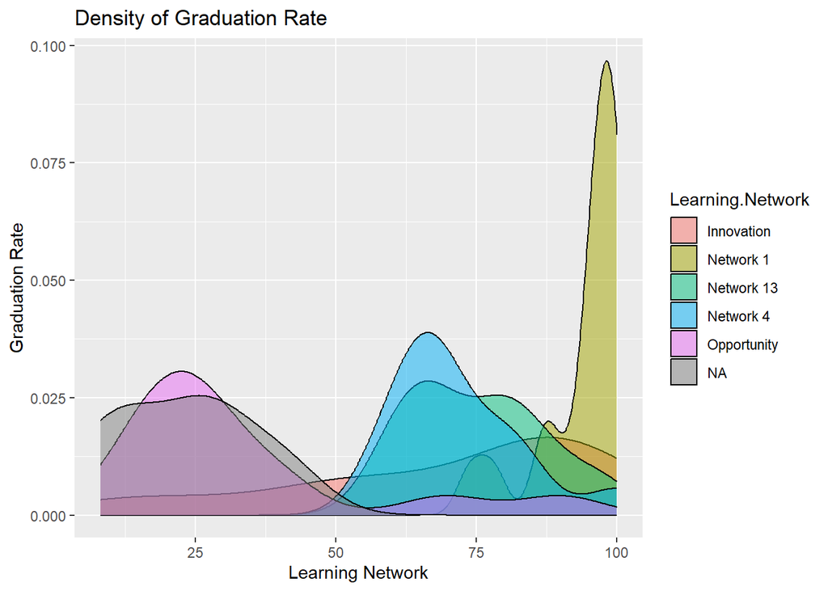

```r
par(mfrow = c(5,1))

ggplot(df.full, aes(x = Grad.Rate, fill = Learning.Network)) +
  geom_density(alpha = 0.5) +
  labs(title = "Density of Graduation Rate", x = "Learning Network", y = "Graduation Rate")
```

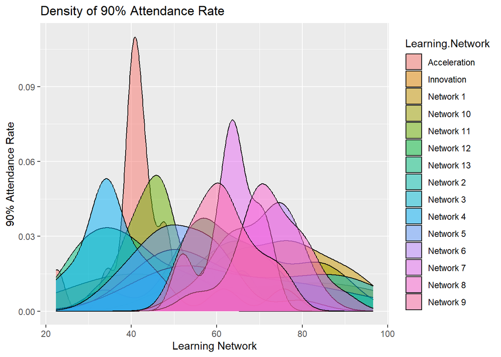

```r
ggplot(df.full, aes(x = Attendance.90.Rate, fill = Learning.Network)) +
  geom_density(alpha = 0.5) +
  labs(title = "Density of 90% Attendance Rate", x = "Learning Network", y = "90% Attendance Rate")
```

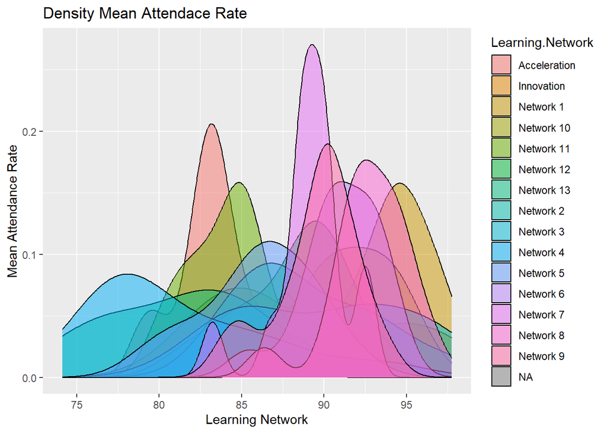

```r
ggplot(df.full, aes(x = Mean.Attendance, fill = Learning.Network)) +
  geom_density(alpha = 0.5) +
  labs(title = "Density Mean Attendace Rate", x = "Learning Network", y = "Mean Attendance Rate")
```

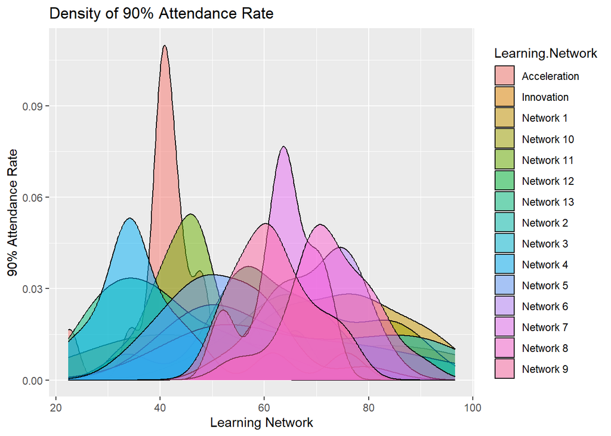

```r
ggplot(df.full, aes(x = Attendance.90.Rate, fill = Learning.Network)) +
  geom_density(alpha = 0.5) +
  labs(title = "Density of 90% Attendance Rate", x = "Learning Network", y = "90% Attendance Rate")
```

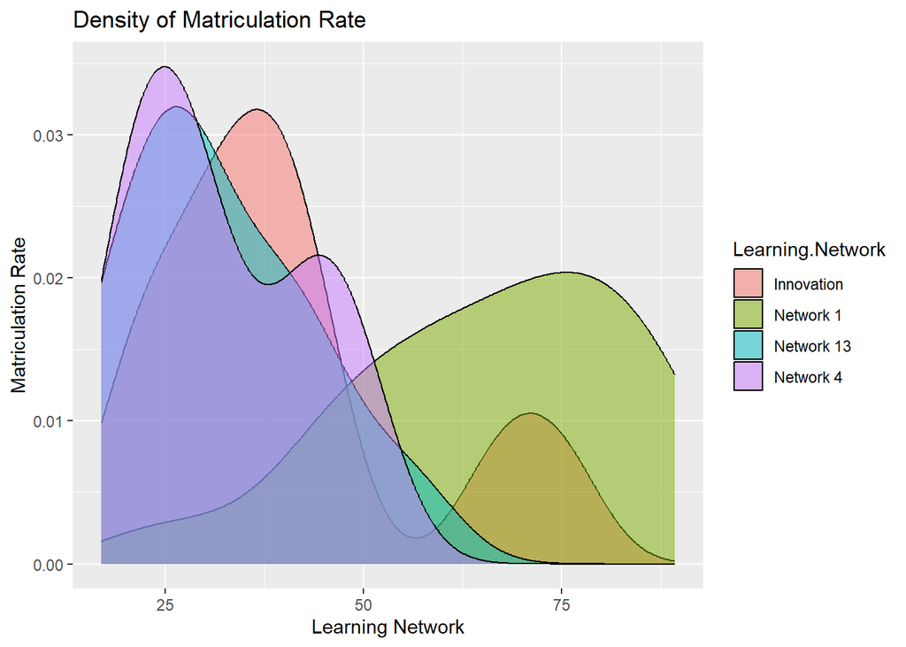

```r
ggplot(df.full, aes(x = First.Fall.Matriculation.Rate, fill = Learning.Network)) +
  geom_density(alpha = 0.5) +
  labs(title = "Density of Matriculation Rate", x = "Learning Network", y = "Matriculation Rate")
```

In our initial overview, we see a possible link between college matriculation rate and Learning Network 1. We will investigate this further later on.

## 3.4 Summary

After making sure our “no-brainer” correlations perform as expected ( For example, `Grad.Cohort.N` and `Total.Students`, were highly correlated - if that was not the case, it would warrant more investigation), we can see possible relationships to explore.

### 3.4.1 Graduation-related Statistics

*High or Marginal Food Security rate - the raw number was correlated with number of graduates, rates with rate* Mean attendance with graduation rate (not raw number) *Graduation Rate with Attendance 90% or higher rate* Learning Network 1 appears to have a much higher rate of graduation

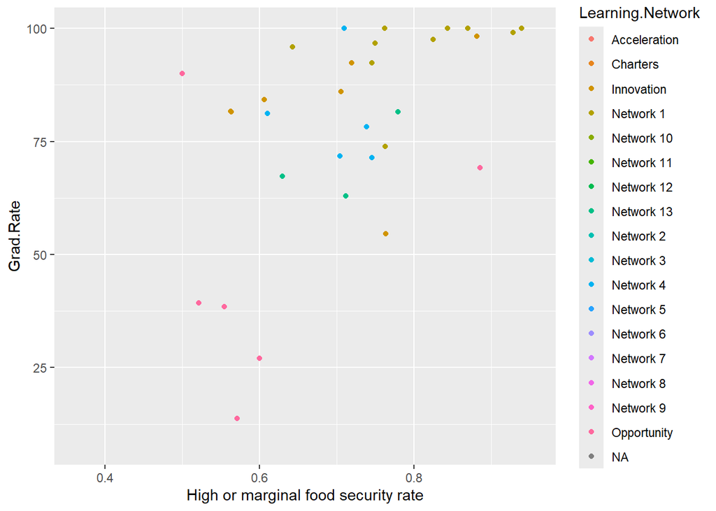

```r
par(mfrow=c(3,1))
ggplot(df.full, aes(x=`High or marginal food security rate`, y=Grad.Rate, color=Learning.Network))+
  geom_point()
```

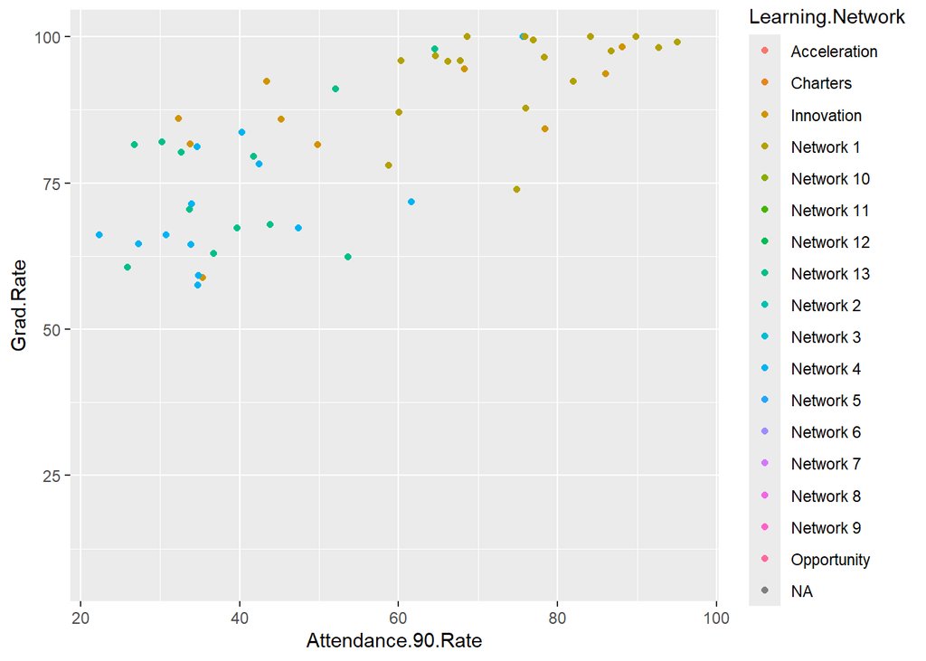

```r
ggplot(df.full, aes(x=Attendance.90.Rate, y=Grad.Rate, color=Learning.Network))+
  geom_point()
```

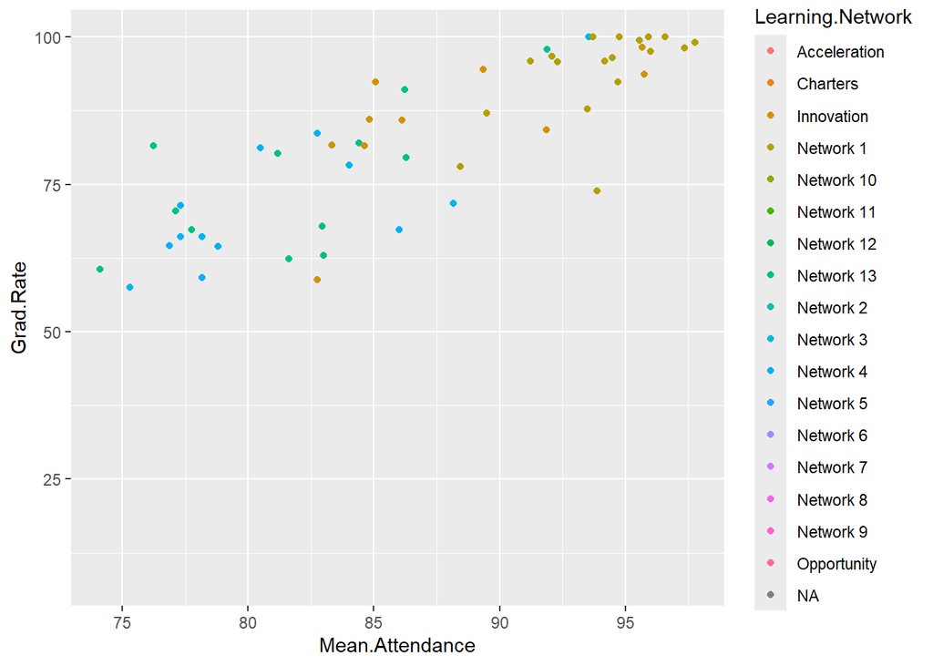

```r
ggplot(df.full, aes(x=Mean.Attendance, y=Grad.Rate, color=Learning.Network))+
  geom_point()
```

### 3.4.2 Attendance Statistics

Mean attendance and rate of students with 90% or higher attendance:

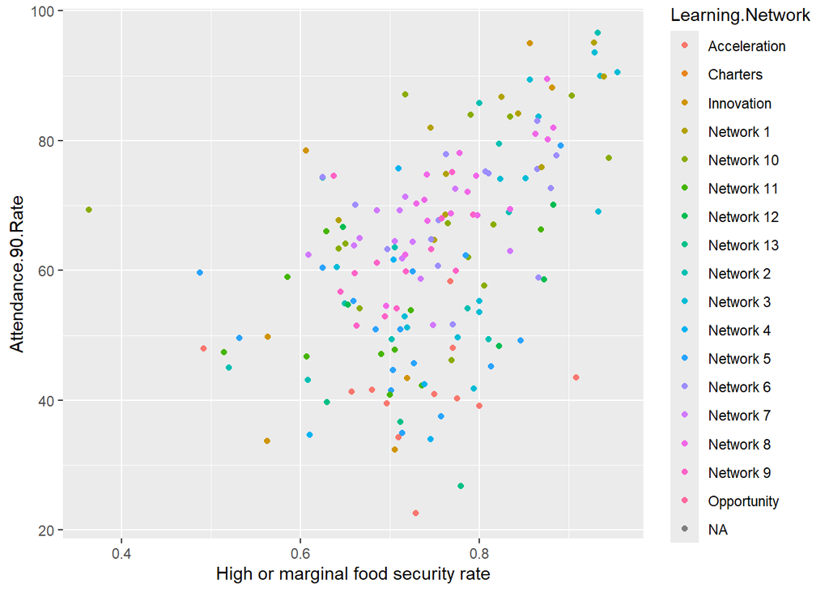

```r
par(mfrow=c(2,1))
ggplot(df.full, aes(x=`High or marginal food security rate`, y=Attendance.90.Rate, color=Learning.Network))+
  geom_point()
```

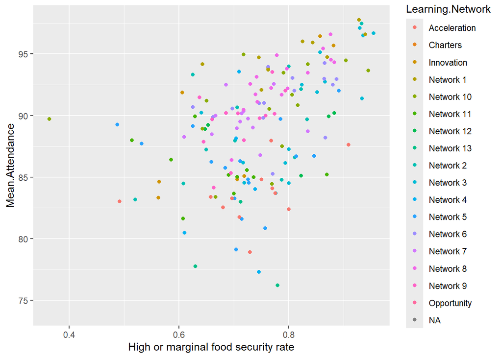

```r
ggplot(df.full, aes(x=`High or marginal food security rate`, y=Mean.Attendance, color=Learning.Network))+
  geom_point()
```

### 3.4.3 First Fall Matriculation Rate

*High correlations with rates of Graduation, Attendance 90%, and High or Marginal Food Security, as well as Mean Attendance* Learning Network 1 appears to have a much higher level of First Fall Matriculation

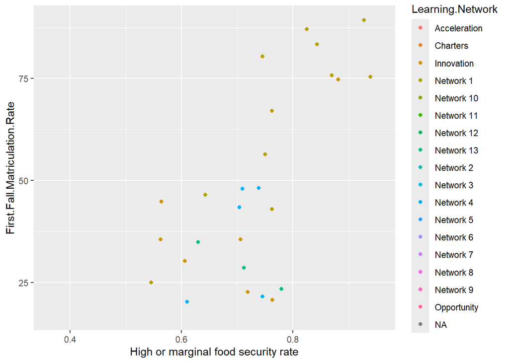

```r
par(mfrow=c(3,1))
ggplot(df.full, aes(x=`High or marginal food security rate`, y=First.Fall.Matriculation.Rate, color=Learning.Network))+
  geom_point()
```

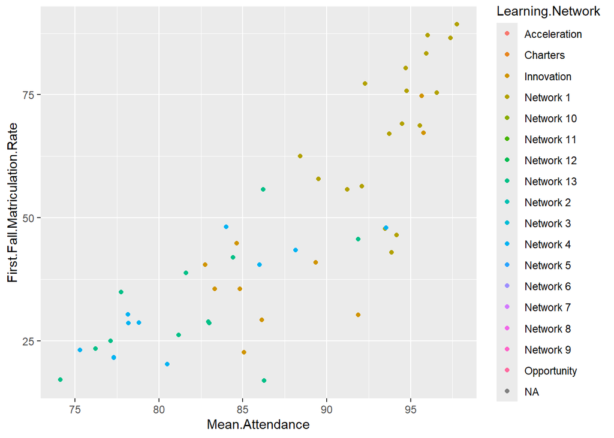

```r
ggplot(df.full, aes(x=Mean.Attendance, y=First.Fall.Matriculation.Rate, color=Learning.Network))+
  geom_point()
```

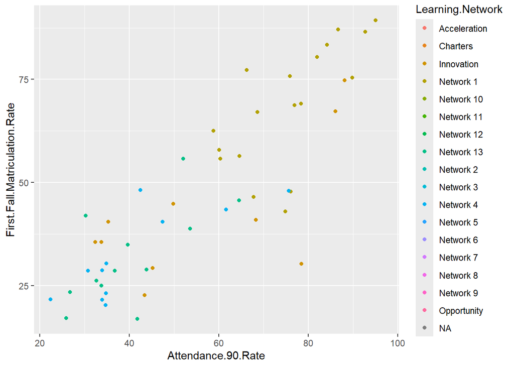

```r
ggplot(df.full, aes(x=Attendance.90.Rate, y=First.Fall.Matriculation.Rate, color=Learning.Network))+
  geom_point()
```

We can see from our plots that Network 1 has multiple schools reporting all of this data, so our plots are not the result of a few high outliers.

# 4 Imputing Missing Values

While we have no shortage of data, we are missing many responses to the food security survey. We saw earlier that a value of `High or marginal food security rate` was highly correlated with many variables of interest. We will explore imputing values of that rate based on existing data.

## 4.1 Finding Variables to use Imputing

Luckily, our dataset includes a variable states whether a school met the reporting criteria. We use this to see whether schools who met the reporting threshold are similar to schools that did not - if they are similar, it may indicate that they could be used as predictors for imputing.

First, the initial boxplots:

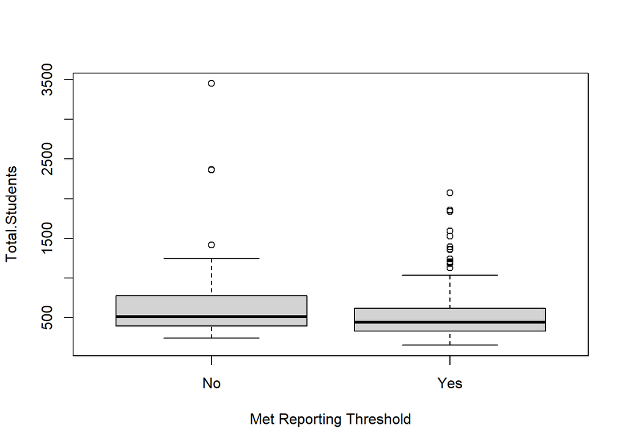

```r
boxplot(Total.Students ~ `Met Reporting Threshold`, data=df.full)
```

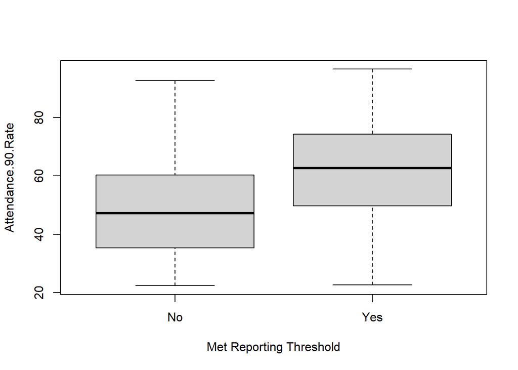

```r
boxplot(Attendance.90.Rate ~ `Met Reporting Threshold`, data=df.full)
```

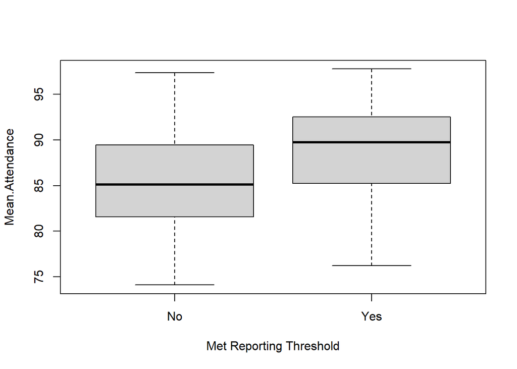

```r
boxplot(Mean.Attendance ~ `Met Reporting Threshold`, data=df.full)
```

## 4.2 Creating a testing set

For ease of programming, we will make a separate dataset for testing and predicting by filtering observations that have or have not met reporting criteria.

To make sure that we have values in each of the variables, we will only consider observations with values in all desired variables for our model building - the alternative returns errors.

```r
df.test<-filter(df.full, `Met Reporting Threshold`=="Yes")
df.pred<-filter(df.full, `Met Reporting Threshold`=="No")

test.fi.columns <- c("Total.Students", "Attendance.90.Rate", "Mean.Attendance", "Learning.Network", "High or marginal food security rate")

df.test2 <- na.omit(df.test[, test.fi.columns])
```

Use of the `summary` function shows that we have 166 observations in our test group and 100 observations looking for predictions.

## 4.3 Testing and Choosing a Model

We will create and judge multiple models below.

### 4.3.1 Linear Regression

A linear regression models the linear relationship between an explanatory variable (or variables) and a response variable. This model is a good predictor when there is reason to believe that a linear relationship exists.

```r
set.seed(215)
fitControl <- trainControl(method = "cv", number = 10)

colnames(df.test2)[5]<-"y"

model.f.lm <- train(y ~ Attendance.90.Rate + Mean.Attendance + Learning.Network + Total.Students,
                  data = df.test2,
                  method = "lm",
                  trControl = fitControl)
model.f.lm
```

```
## Linear Regression
##
## 166 samples
##   4 predictor
##
## No pre-processing
## Resampling: Cross-Validated (10 fold)
## Summary of sample sizes: 149, 150, 150, 150, 150, 149, ...
## Resampling results:
##
##   RMSE        Rsquared   MAE
##   0.09131945  0.1997966  0.07047227
##
## Tuning parameter 'intercept' was held constant at a value of TRUE
```

Our output has two statistics we will compare to the other model, RMSE and Rsquared. The Root Mean Squared Error (RMSE) of a model is a measure of error. Ideally, our model has the lowest RMSE possible. It is calculated with the following equation:

$RMSE=\sqrt{\Sigma_{i=1}^n (\hat{y}-y{i}^2)/n }$

The Rsquared is a measure of correlation. It can range from values of -1 to 1. -1 is a perfect negative relationship, 1 is a perfect positive relation, 0 is no relationship. We would like our Rsquared value to be close to 1.

We will use these two metrics to compare to our models.

### 4.3.2 K-Nearest Neighbors

K-Nearest Neighbors is a non-parametric modeling technique. It is a more flexible model than linear regression, because it does not assume a relationship to be linear. Instead, it selects a value of $K$, then finds an observation’s $k$ nearest neighbors (closest Euclidean distances), and averages those $k$ values of $Y$ for a predicted value.

Since this model uses Euclidean distance, we will scale our variables, meaning the variable `Learning.Network` will be omitted.

```r
set.seed(215)
df.test.sc<-scale(df.test2[sapply(df.test2, is.numeric)])

kGrid <- expand.grid(k = seq(1, 9, by = 2))

model.f.knn <- train(y ~ Attendance.90.Rate + Mean.Attendance + Total.Students,
                  data = df.test.sc,
                  method = "knn",
                  tuneGrid=kGrid,
                  trControl = fitControl)
model.f.knn
```

```
## k-Nearest Neighbors
##
## 166 samples
##   3 predictor
##
## No pre-processing
## Resampling: Cross-Validated (10 fold)
## Summary of sample sizes: 149, 150, 150, 150, 150, 149, ...
## Resampling results across tuning parameters:
##
##   k  RMSE       Rsquared   MAE
##   1  1.0737927  0.2227345  0.8049111
##   3  0.8798277  0.2642650  0.6622007
##   5  0.8545068  0.2801964  0.6382201
##   7  0.8671810  0.2515185  0.6620567
##   9  0.8626043  0.2615930  0.6517745
##
## RMSE was used to select the optimal model using the smallest value.
## The final value used for the model was k = 5.
```

### 4.3.3 Random Forest

A Random Forest model is an ensemble model that creates multiple uncorrelated decision trees and arrives at a final value by averaging their results. The difference between it an bagging is the number of explanatory variables considered at each split of the tree - a random forest will consider fewer, chosen at random, meaning more variables are likely to be considered at each tree.

```r
set.seed(215)

mtryGrid <- expand.grid(mtry = 2:4)
model.f.rf <- train(y ~ Attendance.90.Rate + Mean.Attendance + Learning.Network + Total.Students,
                  data = df.test2,
                  method = "rf",
                  tuneGrid=mtryGrid,
                  trControl = fitControl)

model.f.rf
```

```
## Random Forest
##
## 166 samples
##   4 predictor
##
## No pre-processing
## Resampling: Cross-Validated (10 fold)
## Summary of sample sizes: 149, 150, 150, 150, 150, 149, ...
## Resampling results across tuning parameters:
##
##   mtry  RMSE        Rsquared   MAE
##   2     0.08416373  0.2979702  0.06427202
##   3     0.08452474  0.2881506  0.06360419
##   4     0.08516851  0.2836429  0.06363314
##
## RMSE was used to select the optimal model using the smallest value.
## The final value used for the model was mtry = 2.
```

## 4.4 Conclusion

# 5 Unsupervised Learning

## 5.1 Overview

Unsupervised learning is used when there is no $Y$ variable, meaning, we are not looking for a relationship between a group of explanatory variables and a response variable of interest. We can use various unsupervised learning techniques to conduct analyses like examining relationships between variables or putting observations into clusters based on certain characteristics.

## 5.2 Clustering

### 5.2.1 Preparing and Scaling the Data

Clustering can depend heavily on each variable’s units of measurement. To account for this, we will first scale our dataset. We will also remove redundant variables that are inherently correlated with one another. For example, instead of including the raw number of graduates and graduation rate, we will just include the rate.

Since our clustering function requires non-missing values, we will attempt to remove variables with many missing values - we don’t want to reduce our sample size by too much! This means we will have to drop food security scores for now, as too many are missing and we have no viable way to impute them.

We will also cluster high schools and non-high schools (referred to as elementary for simplicity) because high schools have more variables related to them - graduation and college matriculation stats do not exist for elementary schools - and we want to use information when we can.

```r
df.hs <- df.full[,-c(12:21)] %>% filter(!is.na(Grad.Cohort.N))%>% na.omit

df.elem <- df.full[,-c(12:21)] %>% filter(is.na(Grad.Cohort.N))

df.elem<-df.elem[,-c(6:10)]%>%na.omit


df.hs.sc<-scale(df.hs[sapply(df.hs, is.numeric)])

df.el.sc<-scale(df.elem[sapply(df.elem, is.numeric)])
```

### 5.2.2 K-Means

K-Means is an algorithm that partitions observations. This means that each observation will fall in one - and only one - cluster. It measures this with Euclidean Distances, a numerical value that generally warrants using scaled data.

To find a point of diminishing returns, we will use a scree plot and look for an ‘elbow’ - a point where the reduction of variance hits a low plateau. We will test around k=13 clusters, the existing number of Neighborhood Networks in the School District of Philadelphia (not counting Acceleration, Opportunity, Charter, or Innovation Schools)

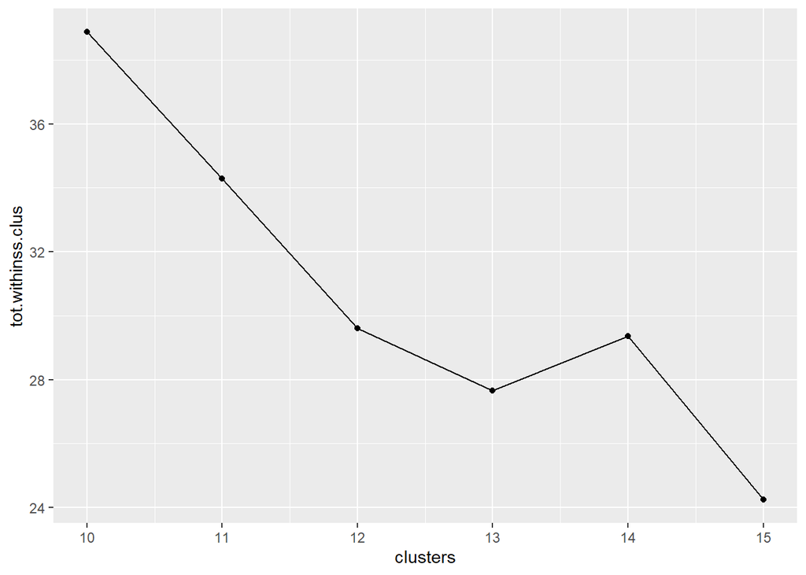

```r
set.seed(215)
km.hs.10.sc<-kmeans(df.hs.sc, 10, nstart=20)
km.hs.11.sc<-kmeans(df.hs.sc, 11, nstart=20)
km.hs.12.sc<-kmeans(df.hs.sc, 12, nstart=20)
km.hs.13.sc<-kmeans(df.hs.sc, 13, nstart=20)
km.hs.14.sc<-kmeans(df.hs.sc, 14, nstart=20)
km.hs.15.sc<-kmeans(df.hs.sc, 15, nstart=20)

clusters <- 10:15

tot.withinss.clus <- c(km.hs.10.sc$tot.withinss, km.hs.11.sc$tot.withinss, km.hs.12.sc$tot.withinss, km.hs.13.sc$tot.withinss,km.hs.14.sc$tot.withinss, km.hs.15.sc$tot.withinss)

frame <- data.frame(clusters, tot.withinss.clus)

ggplot(frame, aes(x = clusters, y = tot.withinss.clus)) +
  geom_point() +
  geom_line()
```

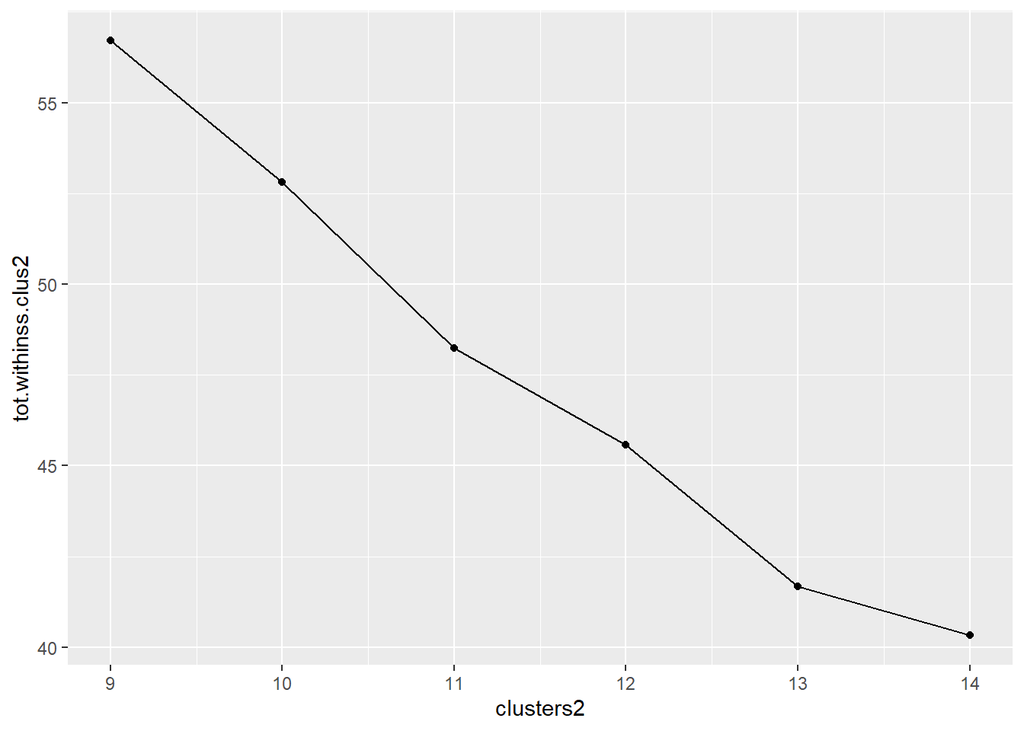

```r
set.seed(215)
km.el.11.sc<-kmeans(df.el.sc, 11, nstart=20)
km.el.12.sc<-kmeans(df.el.sc, 12, nstart=20)
km.el.13.sc<-kmeans(df.el.sc, 13, nstart=20)
km.el.14.sc<-kmeans(df.el.sc, 14, nstart=20)
km.el.15.sc<-kmeans(df.el.sc, 15, nstart=20)
km.el.16.sc<-kmeans(df.el.sc, 16, nstart=20)

clusters2 <- 9:14

tot.withinss.clus2 <- c(km.el.11.sc$tot.withinss,   km.el.12.sc$tot.withinss, km.el.13.sc$tot.withinss, km.el.14.sc$tot.withinss, km.el.15.sc$tot.withinss, km.el.16.sc$tot.withinss)

frame <- data.frame(clusters2, tot.withinss.clus2)

ggplot(frame, aes(x = clusters2, y = tot.withinss.clus2)) +
  geom_point() +
  geom_line()
```

### 5.2.3 Comparing

Now, we will see if observations were clustered with schools in the same Learning Network (for example, an instance two schools in Learning Network 1 were placed in cluster 5). We will also count the number of times this happened.

```r
hs.labels<- km.hs.12.sc$cluster
el.labels<-km.el.13.sc$cluster

df.hs.clus<- df.hs %>%
  mutate(Cluster = factor(hs.labels))

df.el.clus<- df.elem %>%
  mutate(Cluster = factor(el.labels))

match.hs <- df.hs.clus %>%
  group_by(Learning.Network, Cluster) %>%
  summarise(count = n(), .groups = 'drop') %>%
  filter(count > 1)

match.el <- df.el.clus %>%
  group_by(Learning.Network, Cluster) %>%
  summarise(count = n(), .groups = 'drop') %>%
  filter(count > 1)

match.hs
```

```
## # A tibble: 14 × 3
##    Learning.Network Cluster count
##    <chr>            <fct>   <int>
##  1 Innovation       1           2
##  2 Innovation       8           4
##  3 Innovation       9           2
##  4 Network 1        1           3
##  5 Network 1        4           3
##  6 Network 1        9           3
##  7 Network 1        10          4
##  8 Network 1        12          3
##  9 Network 13       3           3
## 10 Network 13       7           3
## 11 Network 13       8           2
## 12 Network 13       11          3
## 13 Network 4        3           5
## 14 Network 4        6           2
```

```r
colSums(match.hs[3])
```

```
## count
##    42
```

```r
nrow(df.hs.clus)
```

```
## [1] 51
```

```r
match.el
```

```
## # A tibble: 35 × 3
##    Learning.Network Cluster count
##    <chr>            <fct>   <int>
##  1 Acceleration     4           8
##  2 Acceleration     11          4
##  3 Network 10       1           5
##  4 Network 10       3           2
##  5 Network 10       6           2
##  6 Network 10       13          2
##  7 Network 11       4           6
##  8 Network 11       5           3
##  9 Network 11       11          6
## 10 Network 12       1           3
## # ℹ 25 more rows
```

```r
colSums(match.el[3])
```

```
## count
##   130
```

```r
nrow(df.el.clus)
```

```
## [1] 162
```

### 5.2.4 Conclusion

Cluster analysis shows promise for grouping schools with minimal demographic information. This may be helpful for targeted programs in the future. Our cluster analysis also shows that many Learning Networks have schools that are similar enough to be clustered together.

# 6 Predictive Modeling

## 6.1 Overview

Supervised learning is used to examine relationships between explanatory variable(s) and a response variable. We can use supervised learning techniques to look for and measure associations between those variables.

We will look at two response variables, Graduation Rate and College Matriculation Rate. For each response variable, we will fit two different models and compare them. We will use different models for the sake of demonstrating multiple statistical techniques, but in practice, we could also find that the same model type could be the best for both variables.

We will fit models both with and without statistics related to food insecurity to see if these are good predictors. While we believe that they could be, requiring them for our model effectively cuts our sample in half.

If a model was used before, in the imputing section of this report, an overview of the model will not be given. Please reference that section of the report if you would like a reminder.

## 6.2 Graduation

### 6.2.1 Linear Regression

Since we saw evidence of a linear relationship between graduation rate and possible explanatory variables earlier, we will first fit a linear model using our explanatory variables of interest.

```r
grad.rate.columns1 <- c("Grad.Rate", "Attendance.90.Rate", "Mean.Attendance", "Learning.Network", "High or marginal food security rate")

grad.rate.columns2 <- c("Grad.Rate", "Attendance.90.Rate", "Mean.Attendance", "Learning.Network")

df.grad.rate1 <- na.omit(df.full[, grad.rate.columns1])
df.grad.rate2 <- na.omit(df.full[, grad.rate.columns2])

set.seed(215)
fitControl <- trainControl(method = "cv", number = 10)

model.lm.1 <- train(Grad.Rate ~ Attendance.90.Rate + Mean.Attendance + Learning.Network + `High or marginal food security rate`,
                  data = df.grad.rate1,
                  method = "lm",
                  trControl = fitControl)

model.lm.2 <- train(Grad.Rate ~ Attendance.90.Rate + Mean.Attendance + Learning.Network,
                  data = df.grad.rate2,
                  method = "lm",
                  trControl = fitControl)

model.lm.1
```

```
## Linear Regression
##
## 24 samples
##  4 predictor
##
## No pre-processing
## Resampling: Cross-Validated (10 fold)
## Summary of sample sizes: 22, 21, 22, 21, 22, 21, ...
## Resampling results:
##
##   RMSE      Rsquared  MAE
##   11.10018  0.896766  9.717691
##
## Tuning parameter 'intercept' was held constant at a value of TRUE
```

```r
model.lm.2
```

```
## Linear Regression
##
## 53 samples
##  3 predictor
##
## No pre-processing
## Resampling: Cross-Validated (10 fold)
## Summary of sample sizes: 48, 48, 49, 48, 48, 48, ...
## Resampling results:
##
##   RMSE      Rsquared   MAE
##   7.645405  0.7788506  5.940528
##
## Tuning parameter 'intercept' was held constant at a value of TRUE
```

Like before, we will use the RMSE and R-Squared to compare to our models. Our strongest model appears to be the smaller, 3 predictor model, possibly owing to the larger sample size.

### 6.2.2 K-Nearest Neighbors

We will again remove the `Learning.Network` variable and scale our data.

```r
set.seed(215)
kGrid <- expand.grid(k = seq(1, 15, by = 2))

df.grad.rate.sc1<-scale(df.grad.rate1[sapply(df.grad.rate1, is.numeric)])
df.grad.rate.sc2<-scale(df.grad.rate2[sapply(df.grad.rate2, is.numeric)])

model.knn.1 <- train(Grad.Rate ~ Attendance.90.Rate + Mean.Attendance + `High or marginal food security rate`,
                  data = df.grad.rate.sc1,
                  method = "knn",
                  tuneGrid=kGrid,
                  trControl = fitControl)
model.knn.2 <- train(Grad.Rate ~ Attendance.90.Rate + Mean.Attendance,
                  data = df.grad.rate.sc2,
                  method = "knn",
                  tuneGrid=kGrid,
                  trControl = fitControl)

model.knn.1
```

```
## k-Nearest Neighbors
##
## 24 samples
##  3 predictor
##
## No pre-processing
## Resampling: Cross-Validated (10 fold)
## Summary of sample sizes: 22, 21, 22, 21, 22, 21, ...
## Resampling results across tuning parameters:
##
##   k   RMSE       Rsquared   MAE
##    1  1.0073264  0.9332069  0.8917428
##    3  0.8327335  0.9159549  0.7331651
##    5  0.8002814  0.8863490  0.7060056
##    7  0.7459571  0.9891854  0.6834596
##    9  0.6677456  0.9431335  0.6030167
##   11  0.7031781  0.9995013  0.6295043
##   13  0.7231276  0.9938993  0.6229354
##   15  0.7909955  0.9940330  0.7091873
##
## RMSE was used to select the optimal model using the smallest value.
## The final value used for the model was k = 9.
```

```r
model.knn.2
```

```
## k-Nearest Neighbors
##
## 53 samples
##  2 predictor
##
## No pre-processing
## Resampling: Cross-Validated (10 fold)
## Summary of sample sizes: 45, 49, 47, 49, 47, 49, ...
## Resampling results across tuning parameters:
##
##   k   RMSE       Rsquared   MAE
##    1  0.7373540  0.6101615  0.5674889
##    3  0.6804405  0.6506163  0.5600009
##    5  0.6623327  0.6489019  0.5491155
##    7  0.6175740  0.6918347  0.5265225
##    9  0.6038680  0.6913957  0.5050075
##   11  0.6018476  0.6995380  0.5107941
##   13  0.6043374  0.6975269  0.5205515
##   15  0.6037273  0.7088343  0.5229349
##
## RMSE was used to select the optimal model using the smallest value.
## The final value used for the model was k = 11.
```

### 6.2.3 Discussion: Graduation Rate

We attempted to fit two different types of models to graduation rate: a linear model and a K-Nearest Neighbors model. Our goal was to both evaluate the modeling methods and see if a Food Security score was a valuable predictor of graduation rate.

Using RMSE and Rsquared as metrics, we found that the superior model of the 4 was a K-Nearest Neighbor model that sacrificed a predictors and sample size. We would highly recommend further testing this relationship, as the sample size for this was too small to draw any conclusions.

We do not feel that there is strong enough information on whether or not food security rating is a valuable predictor for graduation. This will be elaborated on in our conclusion.

## 6.3 College Matriculation

Similar to graduation rate, we will fit models with and without the Food Security Rate variable and discuss our findings at the end.

```r
mat.rate.columns1 <- c("First.Fall.Matriculation.Rate","Grad.Rate", "Attendance.90.Rate", "Mean.Attendance", "Learning.Network", "High or marginal food security rate")
mat.rate.columns2 <- c("First.Fall.Matriculation.Rate","Grad.Rate", "Attendance.90.Rate", "Mean.Attendance", "Learning.Network")

df.mat.rate1 <- na.omit(df.full[, mat.rate.columns1])
df.mat.rate2 <- na.omit(df.full[, mat.rate.columns2])
```

### 6.3.1 Bootstrap Aggregation

Bootstrap Aggregating (or Bagging) is an ensemble model - meaning multiple models are considered in making a final prediction - that applies a sampling technique called bootstrapping to a model (in this case decision tree model) to reduce variance.

A benefit of bagging is we can see importance of variables in coming up with the regression value, meaning, if we want to see a change in $Y$, we can see which variable had a higher importance in determining its’ value and target it with future interventions.

```r
set.seed(215)

mtryGrid <- expand.grid(mtry = 5)

model.bag.1 <- train(First.Fall.Matriculation.Rate ~ Grad.Rate + Attendance.90.Rate + Mean.Attendance + Learning.Network + `High or marginal food security rate`,
                  data = df.mat.rate1,
                  method = "rf",
                  tuneGrid=mtryGrid,
                  trControl = fitControl)

model.bag.2 <- train(First.Fall.Matriculation.Rate ~ Grad.Rate + Attendance.90.Rate + Mean.Attendance + Learning.Network,
                  data = df.mat.rate2,
                  method = "rf",
                  tuneGrid=mtryGrid,
                  trControl = fitControl)

model.bag.1
```

```
## Random Forest
##
## 24 samples
##  5 predictor
##
## No pre-processing
## Resampling: Cross-Validated (10 fold)
## Summary of sample sizes: 22, 21, 22, 21, 22, 21, ...
## Resampling results:
##
##   RMSE      Rsquared   MAE
##   12.16627  0.9158526  10.91142
##
## Tuning parameter 'mtry' was held constant at a value of 5
```

```r
model.bag.2
```

```
## Random Forest
##
## 51 samples
##  4 predictor
##
## No pre-processing
## Resampling: Cross-Validated (10 fold)
## Summary of sample sizes: 47, 47, 47, 45, 46, 45, ...
## Resampling results:
##
##   RMSE    Rsquared   MAE
##   10.053  0.7818939  8.018517
##
## Tuning parameter 'mtry' was held constant at a value of 5
```

Our preferred model appears to be larger sample size, losing food security as a predictor.

### 6.3.2 Random Forest

As explained before, this is similar to Bagging, but our models consider a smaller number of predictors at each node.

```r
set.seed(215)

mtryGrid <- expand.grid(mtry = 2:4)

model.rf1 <- train(First.Fall.Matriculation.Rate ~ Grad.Rate + Attendance.90.Rate + Mean.Attendance + Learning.Network + `High or marginal food security rate`,
                  data = df.mat.rate1,
                  method = "rf",
                  tuneGrid=mtryGrid,
                  trControl = fitControl)

model.rf2 <- train(First.Fall.Matriculation.Rate ~ Grad.Rate + Attendance.90.Rate + Mean.Attendance + Learning.Network,
                  data = df.mat.rate2,
                  method = "rf",
                  tuneGrid=mtryGrid,
                  trControl = fitControl)
model.rf1
```

```
## Random Forest
##
## 24 samples
##  5 predictor
##
## No pre-processing
## Resampling: Cross-Validated (10 fold)
## Summary of sample sizes: 22, 21, 22, 21, 22, 21, ...
## Resampling results across tuning parameters:
##
##   mtry  RMSE      Rsquared   MAE
##   2     11.27513  0.9289897  10.23220
##   3     11.67550  0.9202264  10.41929
##   4     11.89342  0.9192672  10.60459
##
## RMSE was used to select the optimal model using the smallest value.
## The final value used for the model was mtry = 2.
```

```r
model.rf2
```

```
## Random Forest
##
## 51 samples
##  4 predictor
##
## No pre-processing
## Resampling: Cross-Validated (10 fold)
## Summary of sample sizes: 47, 46, 47, 45, 46, 45, ...
## Resampling results across tuning parameters:
##
##   mtry  RMSE       Rsquared   MAE
##   2      9.773751  0.7972231  8.254662
##   3     10.066566  0.7864200  8.417364
##   4     10.166365  0.7801093  8.469978
##
## RMSE was used to select the optimal model using the smallest value.
## The final value used for the model was mtry = 2.
```

Like our bagging models, our best performing model used a larger sample size with one less predictor.

```r
varImp(model.rf1)
```

```
## rf variable importance
##
##                                       Overall
## Mean.Attendance                       100.000
## Attendance.90.Rate                     78.029
## Grad.Rate                              77.580
## `High or marginal food security rate`  55.725
## Learning.NetworkNetwork 1              35.152
## Learning.NetworkNetwork 4               2.213
## Learning.NetworkNetwork 13              0.000
```

```r
varImp(model.rf2)
```

```
## rf variable importance
##
##                            Overall
## Mean.Attendance            100.000
## Attendance.90.Rate          83.780
## Grad.Rate                   64.914
## Learning.NetworkNetwork 1   43.276
## Learning.NetworkNetwork 13   1.121
## Learning.NetworkNetwork 4    0.000
```

A school’s mean attendance appears to be a strong indicator of its eventual college matriculation rate, but Learning Network 1 schools clearly have an advantage on college placement.

### 6.3.3 Discussion: College Matriculation Rate

We attempted to fit two different types of models to College Matriculation rate: a Bagging model and a Random Forest model. We also attempted to evaluate the efficacy of High or Marginal Food Security rate as a predictor of college matriculation. We found that a Random Forest model with m=2 was the superior model, and that, in our initial findings, food security rating does not appear necessary to make the ‘optimal’ predictor.

We would like to caution against definitively stating that it is not a valuable predictor and will elaborate in our conclusion.

Of note, learning Network 1 is a strong predictor for college matriculation, but not graduation. As the current network structure has schools in the same network spread across the city, it is hard to get the demographics for a single network. Further analysis would have been recommended to see if network designation is functionally a stand-in for an economic demographic, but the district is planning on changing their Learning Network boundaries ahead of SY 2024-25, so any analysis of soon-to-be outdated Learning Networks would likely be moot.

# 7 Conclusion

## 7.1 General Observations and Recommendations

The School District of Philadelphia’s collection and sharing of data is admirable and impressive. The existing infrastructure is more than enough to generate many data-based solutions, initiatives, etc. We would recommend a uniform practice for data formatting. In just 5 base datasets, we can see various formatting for the same variable names (`UCLS.Code` vs `schoolid_ucls`), character variables (`John Bartram High School` vs `Bartram, John High School`), numeric variables (percentages in number form vs percentages with a “%” at the end, making them character variables), and how missing values are kept (blank vs “s” or “S”). While it would be time-consuming, a standardized approach to all of this would make working with data much easier and could save time overall.

## 7.2 Recommendations Based on Supervised Learning

We would like to caution that our supervised learning was conducted with a small subset of the data, as the response variables we used only applied to high schools (graduation and college matriculation rate).

Based on our findings, it is our belief that a high attendance is paramount to student - and subsequently school - success in the both graduation and college matriculation metrics. We feel that the district is right to make regular student attendance a high priority. While it is likely very difficult, we would also recommend attempting to collect data on students post-high school paths that do not include college. While college matriculation is likely the easiest to record, knowledge of student placement in other ‘successful’ paths - apprenticeships, jobs, etc - could be a valuable student success metric as college enrollment continues a decade-plus of decline.

We also believe that a school’s food security rating may prove to be a useful predictor of graduation rate. We would recommend checking available data from previous school years (especially prior to the COVID-19 pandemic) using methods similar to the ones demonstrated in this report.